# Regresja i analiza wariancji - Laboratorium 8

Regresja logistyczna - ocena jakości modelu

Adrian Kowalski

Politechnika Krakowska

```r
library(tidyverse)
breast <- readr::read_csv('breast.csv')
```

```
* `` -> ...33
Warning: One or more parsing issues, see `problems()` for details
```

```r
breast <- breast %>% dplyr::select(-c('id','...33')) %>%
          dplyr::mutate(diagnosis = ifelse(diagnosis == 'M', 1, 0)) %>%
          dplyr::mutate(diagnosis = as.factor(diagnosis))
unique(breast$diagnosis)
```

```
[1] 1 0
Levels: 0 1
```

```r
summary(breast)
```

```
 diagnosis  radius_mean      texture_mean   perimeter_mean     area_mean      smoothness_mean
 0:356     Min.   : 6.981   Min.   : 9.71   Min.   : 43.79   Min.   : 143.5   Min.   :0.06251
 1:212     1st Qu.:11.707   1st Qu.:16.17   1st Qu.: 75.20   1st Qu.: 420.3   1st Qu.:0.08640
           Median :13.375   Median :18.84   Median : 86.29   Median : 551.4   Median :0.09589
           Mean   :14.139   Mean   :19.28   Mean   : 92.05   Mean   : 655.7   Mean   :0.09644
           3rd Qu.:15.797   3rd Qu.:21.79   3rd Qu.:104.15   3rd Qu.: 784.1   3rd Qu.:0.10533
           Max.   :28.110   Max.   :39.28   Max.   :188.50   Max.   :2501.0   Max.   :0.16340
 compactness_mean  concavity_mean    concave points_mean symmetry_mean    fractal_dimension_mean
 Min.   :0.01938   Min.   :0.00000   Min.   :0.00000     Min.   :0.1060   Min.   :0.04996
 1st Qu.:0.06517   1st Qu.:0.02958   1st Qu.:0.02035     1st Qu.:0.1620   1st Qu.:0.05770
 Median :0.09312   Median :0.06155   Median :0.03360     Median :0.1792   Median :0.06155
 Mean   :0.10445   Mean   :0.08896   Mean   :0.04901     Mean   :0.1812   Mean   :0.06280
 3rd Qu.:0.13043   3rd Qu.:0.13100   3rd Qu.:0.07401     3rd Qu.:0.1957   3rd Qu.:0.06613
 Max.   :0.34540   Max.   :0.42680   Max.   :0.20120     Max.   :0.3040   Max.   :0.09744
   radius_se        texture_se      perimeter_se       area_se        smoothness_se      compactness_se
 Min.   :0.1115   Min.   :0.3602   Min.   : 0.757   Min.   :  6.802   Min.   :0.001713   Min.   :0.002252
 1st Qu.:0.2324   1st Qu.:0.8331   1st Qu.: 1.605   1st Qu.: 17.850   1st Qu.:0.005166   1st Qu.:0.013133
 Median :0.3240   Median :1.1080   Median : 2.285   Median : 24.565   Median :0.006374   Median :0.020460
 Mean   :0.4052   Mean   :1.2165   Mean   : 2.867   Mean   : 40.374   Mean   :0.007041   Mean   :0.025515
 3rd Qu.:0.4798   3rd Qu.:1.4743   3rd Qu.: 3.360   3rd Qu.: 45.237   3rd Qu.:0.008151   3rd Qu.:0.032455
 Max.   :2.8730   Max.   :4.8850   Max.   :21.980   Max.   :542.200   Max.   :0.031130   Max.   :0.135400
  concavity_se     concave points_se   symmetry_se       fractal_dimension_se  radius_worst   texture_worst
 Min.   :0.00000   Min.   :0.000000   Min.   :0.007882   Min.   :0.0008948    Min.   : 7.93   Min.   :12.02
 1st Qu.:0.01510   1st Qu.:0.007663   1st Qu.:0.015128   1st Qu.:0.0022445    1st Qu.:13.03   1st Qu.:21.07
 Median :0.02592   Median :0.010950   Median :0.018725   Median :0.0031955    Median :14.97   Median :25.41
 Mean   :0.03195   Mean   :0.011817   Mean   :0.020531   Mean   :0.0037967    Mean   :16.28   Mean   :25.67
 3rd Qu.:0.04212   3rd Qu.:0.014730   3rd Qu.:0.023398   3rd Qu.:0.0045585    3rd Qu.:18.80   3rd Qu.:29.68
 Max.   :0.39600   Max.   :0.052790   Max.   :0.078950   Max.   :0.0298400    Max.   :36.04   Max.   :49.54
 perimeter_worst    area_worst     smoothness_worst  compactness_worst concavity_worst  concave points_worst
 Min.   : 50.41   Min.   : 185.2   Min.   :0.07117   Min.   :0.02729   Min.   :0.0000   Min.   :0.00000
 1st Qu.: 84.15   1st Qu.: 515.7   1st Qu.:0.11660   1st Qu.:0.14758   1st Qu.:0.1159   1st Qu.:0.06497
 Median : 97.67   Median : 686.5   Median :0.13135   Median :0.21300   Median :0.2275   Median :0.10002
 Mean   :107.35   Mean   : 881.7   Mean   :0.13244   Mean   :0.25460   Mean   :0.2727   Mean   :0.11481
 3rd Qu.:125.53   3rd Qu.:1085.0   3rd Qu.:0.14602   3rd Qu.:0.33930   3rd Qu.:0.3835   3rd Qu.:0.16168
 Max.   :251.20   Max.   :4254.0   Max.   :0.22260   Max.   :1.05800   Max.   :1.2520   Max.   :0.29100
 symmetry_worst   fractal_dimension_worst
 Min.   :0.1565   Min.   :0.05504
 1st Qu.:0.2504   1st Qu.:0.07147
 Median :0.2821   Median :0.08005
 Mean   :0.2901   Mean   :0.08397
 3rd Qu.:0.3180   3rd Qu.:0.09208
 Max.   :0.6638   Max.   :0.20750
```

# Zbiór treningowy i testowy

Głównym celem budowy modelu klasyfikacji jest predykcja, w takim razie w naszym interesie jest, aby model dobrze się generalizował. Wobec tego podczas budowy modelu musimy zadbać o wykrycie ewentualnych problemów związanych z brakiem balansu w danych, przeuczeniem i obserwacjami odstającymi. Podczas budowania (dowolnego, ale w szczególności klasyfikacji) modelu należy się kierować zasadą “garbage in - garbage out”. Musimy zatem zadbać o to, aby nasze dane były dobrej jakości oraz nie występowały w nich anomalie.

Jednym ze sposobów, warto wspomnieć, że głównym, badania tego jak zbudowany przez nas model będzie się generalizować, jest podział obserwacji na treningowe i testowe. Dane treningowe będą nam służyć podczas procesu uczenia modelu. Dane testowe natomiast nie będą wykorzystywane przy dopasowaniu, będziemy badać na nich wartości wskaźników liczbowych jakości modelu. Najczęściej zbiór treningowy stanowi 3/4 naszych wszystkich obserwacji, ale nie jest to regułą i czasami przyjmuje się inne proporcje.

Uwaga: Jeżeli nasze dane mają strukturę szeregu czasowego, to należy wziąć pod uwagę przyczynowość, którą to ze sobą wiążę. Wówczas nie możemy podzielić danych na treningowe i testowe w sposób losowy, ze względu na efekt tzw. przecieku danych. Przeciek danych polega na prognozowaniu danych “z przeszłości” za pomocą danych “z przyszłości”.

Uwaga: Przy zadaniu klasyfikacji należy zadbać o to, aby dane w zbiorze treningowym i testowym były zbalansowane.

W środowisku R jest wiele sposobów na podział danych na zbiór treningowy i testowy. Ja zaproponuje użycie pakietu *caret*.

```r
library(caret)
train_test_split <- createDataPartition(breast$diagnosis, list = FALSE, p=0.75)
breast_train <- breast[train_test_split,]
breast_test <- breast[-train_test_split,]
cat(dim(breast_train),dim(breast_test))
```

```
426 31 142 31
```

Uwaga: Komenda createDataPartition dba o to, aby balans klas został zachowany taki jak w oryginalnych danych, przez co nie zdarzy się, że w zbiorze testowym znajdą się jedynie obserwacje jednej klasy. Używając innych metod należy o to zadbać!

```r
table(breast$diagnosis)
```

```
  0   1
356 212
```

```r
table(breast_train$diagnosis)
```

```
  0   1
267 159
```

```r
table(breast_test$diagnosis)
```

```
 0  1
89 53
```

Uwaga: Zainteresowanych innymi metodami walki z przeuczeniem odsyłam do zainteresowania się pojęciami “walidacji krzyżowej” i “regularyzacji” (zagadnienia poruszone chociażby w ISLR, ESL, Statystycznych Sytemach uczących się).

# Bazowy model

Zbudujmy prosty bazowy model, na którym będziemy dalej pracować.

```r
summary(breast_train)
```

```
 diagnosis  radius_mean      texture_mean   perimeter_mean     area_mean      smoothness_mean
 0:267     Min.   : 6.981   Min.   : 9.71   Min.   : 43.79   Min.   : 143.5   Min.   :0.06251
 1:159     1st Qu.:11.672   1st Qu.:16.16   1st Qu.: 75.06   1st Qu.: 417.9   1st Qu.:0.08584
           Median :13.210   Median :18.82   Median : 85.56   Median : 538.1   Median :0.09671
           Mean   :14.105   Mean   :19.21   Mean   : 91.80   Mean   : 653.7   Mean   :0.09642
           3rd Qu.:16.060   3rd Qu.:21.66   3rd Qu.:106.10   3rd Qu.: 796.6   3rd Qu.:0.10530
           Max.   :27.420   Max.   :39.28   Max.   :186.90   Max.   :2501.0   Max.   :0.16340
 compactness_mean  concavity_mean    concave points_mean symmetry_mean    fractal_dimension_mean
 Min.   :0.01938   Min.   :0.00000   Min.   :0.00000     Min.   :0.1060   Min.   :0.04996
 1st Qu.:0.06246   1st Qu.:0.02862   1st Qu.:0.02032     1st Qu.:0.1623   1st Qu.:0.05767
 Median :0.09252   Median :0.06168   Median :0.03345     Median :0.1799   Median :0.06164
 Mean   :0.10408   Mean   :0.08819   Mean   :0.04887     Mean   :0.1818   Mean   :0.06292
 3rd Qu.:0.12987   3rd Qu.:0.12878   3rd Qu.:0.07466     3rd Qu.:0.1964   3rd Qu.:0.06631
 Max.   :0.34540   Max.   :0.42680   Max.   :0.20120     Max.   :0.3040   Max.   :0.09744
   radius_se        texture_se      perimeter_se        area_se        smoothness_se      compactness_se
 Min.   :0.1115   Min.   :0.3602   Min.   : 0.7714   Min.   :  6.802   Min.   :0.001713   Min.   :0.002252
 1st Qu.:0.2240   1st Qu.:0.8110   1st Qu.: 1.5477   1st Qu.: 17.008   1st Qu.:0.005042   1st Qu.:0.012982
 Median :0.3150   Median :1.0780   Median : 2.2420   Median : 24.380   Median :0.006282   Median :0.020155
 Mean   :0.4014   Mean   :1.1974   Mean   : 2.8303   Mean   : 39.982   Mean   :0.007072   Mean   :0.025069
 3rd Qu.:0.4955   3rd Qu.:1.4398   3rd Qu.: 3.3502   3rd Qu.: 45.395   3rd Qu.:0.008072   3rd Qu.:0.032107
 Max.   :2.5470   Max.   :4.8850   Max.   :18.6500   Max.   :542.200   Max.   :0.031130   Max.   :0.100600
  concavity_se     concave points_se   symmetry_se       fractal_dimension_se  radius_worst   texture_worst
 Min.   :0.00000   Min.   :0.000000   Min.   :0.007882   Min.   :0.0009502    Min.   : 7.93   Min.   :12.02
 1st Qu.:0.01469   1st Qu.:0.007636   1st Qu.:0.015185   1st Qu.:0.0022183    1st Qu.:12.98   1st Qu.:20.99
 Median :0.02592   Median :0.010920   Median :0.018665   Median :0.0031615    Median :14.80   Median :25.14
 Mean   :0.03163   Mean   :0.011802   Mean   :0.020538   Mean   :0.0037551    Mean   :16.26   Mean   :25.47
 3rd Qu.:0.03992   3rd Qu.:0.014710   3rd Qu.:0.022857   3rd Qu.:0.0045128    3rd Qu.:19.20   3rd Qu.:29.25
 Max.   :0.39600   Max.   :0.052790   Max.   :0.078950   Max.   :0.0298400    Max.   :36.04   Max.   :49.54
 perimeter_worst    area_worst     smoothness_worst  compactness_worst concavity_worst  concave points_worst
 Min.   : 50.41   Min.   : 185.2   Min.   :0.07117   Min.   :0.02729   Min.   :0.0000   Min.   :0.00000
 1st Qu.: 84.01   1st Qu.: 513.3   1st Qu.:0.11685   1st Qu.:0.14442   1st Qu.:0.1144   1st Qu.:0.06425
 Median : 96.56   Median : 662.5   Median :0.13195   Median :0.21655   Median :0.2256   Median :0.10150
 Mean   :107.16   Mean   : 884.0   Mean   :0.13268   Mean   :0.25465   Mean   :0.2718   Mean   :0.11512
 3rd Qu.:127.20   3rd Qu.:1147.0   3rd Qu.:0.14608   3rd Qu.:0.33415   3rd Qu.:0.3824   3rd Qu.:0.16273
 Max.   :251.20   Max.   :4254.0   Max.   :0.22260   Max.   :1.05800   Max.   :1.2520   Max.   :0.29100
 symmetry_worst   fractal_dimension_worst
 Min.   :0.1565   Min.   :0.05504
 1st Qu.:0.2503   1st Qu.:0.07146
 Median :0.2811   Median :0.08014
 Mean   :0.2908   Mean   :0.08414
 3rd Qu.:0.3186   3rd Qu.:0.09213
 Max.   :0.6638   Max.   :0.20750
```

```r
first_model <- glm(diagnosis ~ area_mean , data = breast_train, family='binomial')
summary(first_model)
```

```
Call:
glm(formula = diagnosis ~ area_mean, family = "binomial", data = breast_train)

Deviance Residuals:
     Min        1Q    Median        3Q       Max
-2.30700  -0.42880  -0.17312   0.07687   2.79099

Coefficients:
             Estimate Std. Error z value Pr(>|z|)
(Intercept) -8.380625   0.837964 -10.001   <2e-16 ***
area_mean    0.012462   0.001346   9.258   <2e-16 ***
---
Signif. codes:  0 ‘***’ 0.001 ‘**’ 0.01 ‘*’ 0.05 ‘.’ 0.1 ‘ ’ 1

(Dispersion parameter for binomial family taken to be 1)

    Null deviance: 562.88  on 425  degrees of freedom
Residual deviance: 225.23  on 424  degrees of freedom
AIC: 229.23

Number of Fisher Scoring iterations: 7
```

# Dokładność

Dokładność (accuracy) jest podstawową charakterystyką liczboWą dowolnego modelu klasyfikacji. Pozwala określić jaka część obserwacji w ogóle została zaklasyfikowana poprawnie.

Ustalmy na początek notację, przy klasyfikacji binarnej:

- TP - True Positive - obserwacja “prawdziwa” zaklasyfikowana jako prawdziwa,
- TN - True Negative - obserwacja “fałszywa” zaklasyfikowana jako fałszywa,
- FP - False Positive - obserwacja fałszywa zaklasyfikowana jako prawdziwa,
- FN - False Negative - obserwacja prawdziwa zaklasyfikowana jako fałszywa.

Przy takich oznaczeniach dokładność liczymy jako

$$Acc = \frac{TP + TN}{TP + TN + FP + FN}.$$

Można ją też wyznaczyć dzieląc ślad macierzy pomyłek przez sumę wszystkich jej elementów.

```r
fmpreds <- predict(first_model, breast_test, type = 'response')
fmpreds_classes <- ifelse(fmpreds > 0.5, 1, 0)
table(fmpreds_classes,breast_test$diagnosis )
```

```
fmpreds_classes  0  1
              0 80 16
              1  9 37
```

```r
fm_cm <- caret::confusionMatrix(factor(fmpreds_classes), factor(breast_test$diagnosis))
fm_confusion_matrix <- fm_cm$table
fm_confusion_matrix
```

```
          Reference
Prediction  0  1
         0 80 16
         1  9 37
```

```r
round(sum(diag(fm_confusion_matrix))/sum(fm_confusion_matrix), 2)
```

```
[1] 0.82
```

Wiemy już jak liczyć dokładność, czas wspomnieć o jej największej wadzie. Bazowanie swoich wniosków na temat modelu na dokładności jest poprawne pod warunkiem, że dane były zbalansowane. To, że dane są zbalansowane znaczy, że klasy “0” jest w przybliżeniu tyle samo co klasy “1”. Jeżeli balans klas nie jest zachowany to należy wziąć pod uwagę wynik tzw. klasyfikatora naiwnego (no information rate).

No information rate to wynik jaki uzyskalibyśmy nie korzystając w żaden sposób z danych innych niż rozkład klas. Wtedy przewidywalibyśmy po prostu tą klasę, którą w danych jest najwięcej. Zatem tę wartość liczymy po prostu jako ilość obserwacji z klasy przeważającej podzieloną przez ilość obserwacji.

```r
clbalance <- table(breast_test$diagnosis)
clbalance
```

```
 0  1
89 53
```

```r
round(clbalance[1]/sum(clbalance),2)
```

```
   0
0.63
```

# Wizualizacja macierzy pomyłek

Uwaga: W poniższej implementacji wykresu używamy naszej macierzy pomyłek jako obiektu *data frame*, aby móc użyć funkcjonalności *ggplot*, która zlicza nam wystąpienia, czyli *Freq*.

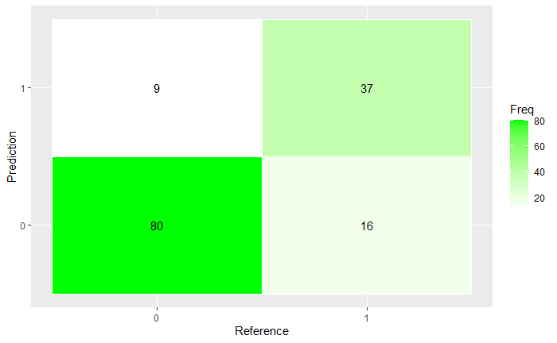

```r
ggplot(as.data.frame(fm_confusion_matrix), aes(x = Reference, y = Prediction)) +
  geom_tile(aes(fill = Freq), colour = 'white') + scale_fill_gradient(low = 'white', high = 'green') +
  geom_text(aes(x = Reference, y = Prediction, label = Freq))
```

# Dewiancja w regresji logistycznej

Zerknijmy jeszcze raz na podsumowanie modelu.

```r
summary(first_model)
```

```
Call:
glm(formula = diagnosis ~ area_mean, family = "binomial", data = breast_train)

Deviance Residuals:
     Min        1Q    Median        3Q       Max
-2.30700  -0.42880  -0.17312   0.07687   2.79099

Coefficients:
             Estimate Std. Error z value Pr(>|z|)
(Intercept) -8.380625   0.837964 -10.001   <2e-16 ***
area_mean    0.012462   0.001346   9.258   <2e-16 ***
---
Signif. codes:  0 ‘***’ 0.001 ‘**’ 0.01 ‘*’ 0.05 ‘.’ 0.1 ‘ ’ 1

(Dispersion parameter for binomial family taken to be 1)

    Null deviance: 562.88  on 425  degrees of freedom
Residual deviance: 225.23  on 424  degrees of freedom
AIC: 229.23

Number of Fisher Scoring iterations: 7
```

Na samym dole podsumowania znajdujemy parametr zwany dewiancją (deviance). Widzimy dwa takie parametry, dewiancja modelu zerowego (null deviance) i dewiancja reszt (residual deviance). W celu wyznaczenia tych wartośći musimy wprowadzić pojęcie modelu nasyconego (saturated model). Model nasycony to taki, w którym każdej obserwacji odpowiada jeden parametr. W takim razie w modelu nasyconym mamy $n$ parametrów do oszacowania, gdzie $n$ to ilość obserwacji. Model zerowy to taki, który ma dokładnie jeden parametr, niezależny od obserwacji.

Dewiancję resztową wyliczamy następująco
$$D = 2(\ell(M_s) - \ell(M_p)).$$
Gdzie

- $\ell$ to log-wiarygodność,
- $M_s$ to model nasycony,
- $M_p$ to model proponowany.

```r
saturated <- glm(diagnosis ~ as.factor(1:length(diagnosis)), data = breast_train, family = 'binomial', maxit=100)
2*(logLik(saturated) - logLik(first_model))
```

```
'log Lik.' 225.2271 (df=426)
```

```r
exp(logLik(saturated))
```

```
'log Lik.' 1 (df=426)
```

```r
nullm <- glm(diagnosis ~ 1, data = breast_train, family = 'binomial')
summary(nullm)
```

[output not shown]

```r
2*(logLik(saturated) - logLik(nullm))
```

[output not shown]

Dewiancja modelu zerowego to najgorsza możliwa wartość dewiancji jaką może przyjąć budowany przez nas model pod warunkiem posiadanych przez nas danych.

Za pomocą dewiancji możemy uzyskać dwie informacje. Pierwszą jest wskaźnik $R^2$ McFaddena, który w pewnym sensie mówi nam o jakości modelu. Jest on jedynie jedną z liczbowych charakterystyk modelu i nie ma już takiej interpretacji jak przy modelu regresji liniowej. Jednak jego małe wartości mogą sugerować bardzo zły model. Definiujemy go wzorem

$$R^2_{pseudo} = 1 - \frac{D}{D_0}.$$
Gdzie $D$ to dewiancja reszt naszego modelu, a $D_0$ dewiancja modelu zerowego.

```r
1 - (2*(logLik(saturated) - logLik(first_model)))/(2*(logLik(saturated) - logLik(nullm)))
```

```
'log Lik.' 0.5998667 (df=426)
```

Drugą informacją jest test na istotność różnicy między modelami. Możemy testować różnice dewiancji $D_1$ jednego modelu o $p$ parametrach i dewiancji $D_2$ drugiego modelu o $q$ parametrach. Wtedy $D_1 - D_2$ ma rozkład $\chi^2$ o $p - q$ stopniach swobody (zakładając, że p>q). W szczególności $D - D_0$ ma rozkład $\chi^2$ o $p$ stopniach swobody.

# Czułość i swoistość

Ważnymi charakterystykami liczbowymi podobnymi do dokładności są czułość i swoistość.

Czułość (sensitivity, recall) definiujemy jako

$$sens = \frac{TP}{TP+FN}.$$

W świetle powyższego wzoru czułość jest stosunkiem poprawnie zaklasyfikowanych zmiennych z klasy “pozytywnej” do ich ilości. Zauważmy, że na czułość już nie ma wpływu zbalansowanie danych, jest ona wręcz często jednym ze znaków świadczących o jego braku.

Swoistość (specificity) jest podobną do czułości wartością, z tym że dotyczącą klasy “negatywnej”. Definiujemy ją wzorem

$$spec = \frac{TN}{TN + FP}.$$

Czyli ponownie mamy stosunek poprawnie zaklasyfikowanych obserwacji z klasy “negatywnej” do ilości obserwacji z tej klasy.

```r
fm_cm
```

```
Confusion Matrix and Statistics

          Reference
Prediction  0  1
         0 80 16
         1  9 37

               Accuracy : 0.8239
                 95% CI : (0.7512, 0.8827)
    No Information Rate : 0.6268
    P-Value [Acc > NIR] : 2.437e-07

                  Kappa : 0.6134

 Mcnemar's Test P-Value : 0.2301

            Sensitivity : 0.8989
            Specificity : 0.6981
         Pos Pred Value : 0.8333
         Neg Pred Value : 0.8043
             Prevalence : 0.6268
         Detection Rate : 0.5634
   Detection Prevalence : 0.6761
      Balanced Accuracy : 0.7985

       'Positive' Class : 0
```

# Cwiczenie

Wróćmy do zbioru danych *heart* i dopasujmy do niego “najlepszy” model regresji logistycznej.

```r
heart <- readr::read_csv('heart.csv')
```

[output not shown]